# Gdzie ludzie sprawdzają prognozę pogody? - Analiza

M. Muzykant

Czerwiec 2021

*Niniejsza analiza stanowi projekt z przedmiotu PjR na kierunku Analityka Biznesowa (2020/2021)*

# Wprowadzenie

Celem projektu jest przedstawienie danych na temat sposobu sprawdzania prognozy pogody przez ludzi z takich rejonów jak Pacyfik, południowy oraz środkowy Atlantyk czy Nowa Anglia. Dane na ten temat zostały zebrane przez Verizon FiOS oraz SurveyMonkey Audience i przedstawione w [tym artykule](https://fivethirtyeight.com/features/weather-forecast-news-app-habits/)

## Obróbka danych

Dane wczytano bezpośrednio z biblioteki fivethirtyeight.

```r
library(fivethirtyeight)
View(weather_check)
```

Składają się z 928 rekordów i 9 zmiennych . Każdy rekord dotyczy pojedynczej osoby badanej.

## Wykorzystane zmienne

W dalszej części analizy wykorzystano następujące zmienne:

| Zmienna | Opis |
| --- | --- |
| *weather_source* | źródło prognozy pogody |
| *age* | wiek |
| *region* | region zamieszkania |
| *sex* | płcie |
| *hhold_income* | przychód (w tyś.USD) |
| *ck_weather_watch* | opinie na temat sprawdzania pogody na smartwatch’u |

### Statystyki podsumowujące wybrane zmienne przedstawiają się następująco:

#### Przedział wiekowy badanych:

```r
knitr::kable(sort(table(weather_check$age), decreasing = TRUE),
             col.names=c("Wiek", "Liczba"))
```

| Wiek | Liczba |
| --- | --- |
| 45 - 59 | 278 |
| 60+ | 258 |
| 30 - 44 | 204 |
| 18 - 29 | 176 |

#### Płeć badanych:

```r
knitr::kable(sort(table(weather_check$sex), decreasing = TRUE),
             col.names=c("Płeć", "Liczba"))
```

| Płeć | Liczba |
| --- | --- |
| Female | 527 |
| Male | 389 |

#### Region, z którego pochodzą badani:

```r
knitr::kable(sort(table(weather_check$region), decreasing = TRUE),
             col.names=c("Region", "Liczba"))
```

| Region | Liczba |
| --- | --- |
| Pacific | 185 |
| South Atlantic | 154 |
| East North Central | 141 |
| Middle Atlantic | 104 |
| West South Central | 94 |
| Mountain | 72 |
| West North Central | 54 |
| New England | 52 |
| East South Central | 41 |

Z powyższych tabeli można odczytać m.in, że największa liczba osób badanych pochodziła z Pacyfiku oraz południowego Atlantyku. Badane osoby były w wiekszośći płci żeńskiej. Największa liczba osób badanych była w wieku 45 - 59.

# Analiza

Przeprowadzona analiza obejmuje następujące zagadnienia:

- analizę przedziału zarobków uczestników badania względem wieku
- analizę opinii na temat sprawdzania prognozy pogody na smartwatch’u
- analizę ilości osób badanych, które korzystają z danego źródła prognozy pogody
- analizę opinii na temat sprawdzania prognozy pogody na smartwatch’u względem wieku
- analizę ilości osób badanych, które korzystają z danego źródła prognozy pogody z uwzględnieniem wieku
- analizę opinii na temat używania smartwatch’a jako źródło sprawdzania pogody względem regionu zamieszkania

## Analiza nr. 1

Celem tej analizy jest przedstawienie zarobków osób badanych wzgledem ich wieku. Do tej analizy zostały wykorzystane zmienne:

| Zmienna | Opis |
| --- | --- |
| *age* | wiek |
| *hhold_income* | przychód (w tyś.USD) |

### Przedział zarobków osób badanych względem wieku

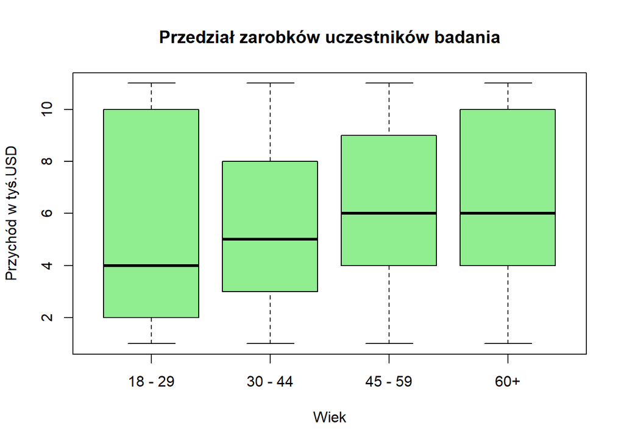

```r
boxplot(weather_check$hhold_income ~ weather_check$age,
        main = "Przedział zarobków uczestników badania",
        xlab = "Wiek", ylab = "Przychód w tyś.USD",col="lightgreen"
)
```

## Analiza nr. 2

Analiza ta ma za zadanie przedstawić opinie na temat sprawdzania prognozy pogody na smartwatch’u, w momencie, w którym posiadałoby się takie urządzenie. Do tej analizy została wykorzystana zmienna:

| Zmienna | Opis |
| --- | --- |
| *ck_weather_watch* | opinie na temat sprawdzania pogody na smartwatch’u |

### Opinie na temat sprawdzania pogody na smartwatch’u

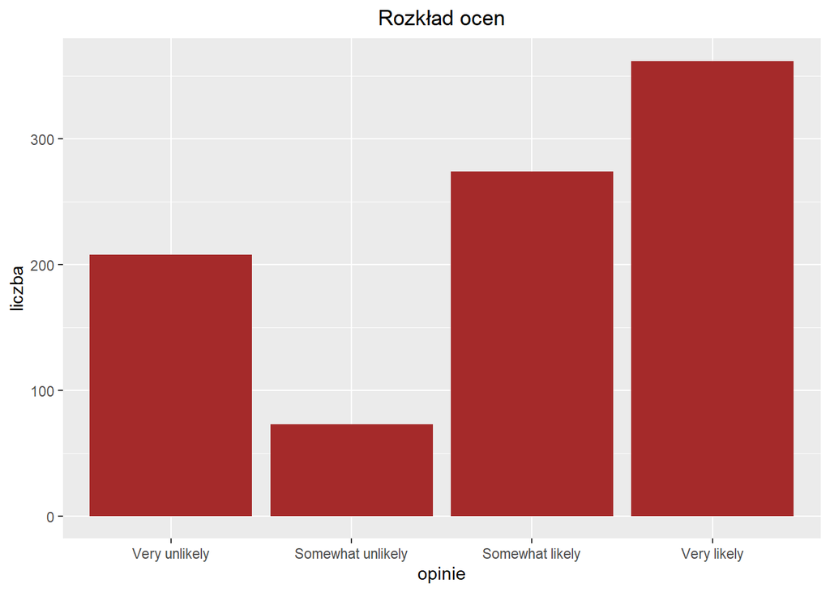

```r
ggplot(weather_check, aes(x =ck_weather_watch)) +
  geom_bar(fill="brown") + ggtitle("Rozkład ocen") +
  xlab("opinie") + ylab("liczba")+ theme(plot.title = element_text(hjust = 0.5))+scale_x_discrete(na.translate = FALSE)
```

## Analiza nr. 3

Analiza ta ma za zadanie przedstawić ilość osób badanych, które sprawdzają prognozę pogody z danego źródła. Do tej analizy została wykorzystana zmienna:

| Zmienna | Opis |
| --- | --- |
| *ck_weather_source* | źródło prognozy pogody |

### Źródła pozyskiwania informacji o pogodzie

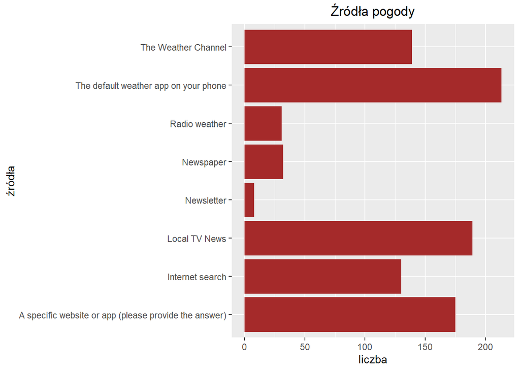

```r
ggplot(weather_check, aes(y = weather_source, )) +
  geom_bar(fill="brown")+ggtitle("Źródła pogody")+
   xlab("liczba") + ylab("źródła")+
 theme(plot.title = element_text(hjust = 0.5))+
  scale_y_discrete(na.translate = FALSE)
```

## Analiza nr. 4

Celem tej analizy jest przedstawienie opinii na temat używania smartwatch’a do sprawdzania prognozy pogody względem wieku badanych. Do tej analizy zostały wykorzystane zmienne:

| Zmienna | Opis |
| --- | --- |
| *ck_weather_watch* | opinie na temat sprawdzania pogody na smartwatch’u |
| *age* | wiek |

### Opinie na temat używania smartwatch’a do sprawdzania prognozy pogody względem wieku

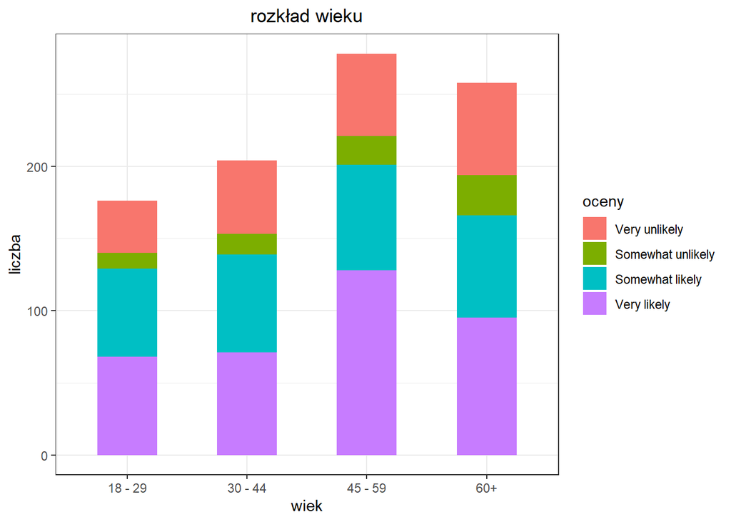

```r
ggplot(weather_check, aes(x = age,fill = ck_weather_watch ))+theme_bw() +
  stat_count(width = 0.5) +
  labs(y="liczba",x="wiek", title="rozkład wieku") +
  scale_fill_discrete(name="oceny")+
  theme(plot.title = element_text(hjust = 0.5))+
  scale_x_discrete(na.translate = FALSE)
```

## Analiza nr. 5

Analiza ta ma za zadania pokazanie używanych źródeł do sprawdzania prognozy pogody z uwzględnieniem wieku. Do tej analizy zostały użyte zmienne:

| Zmienna | Opis |
| --- | --- |
| *ck_weather_source* | źródło prognozy pogody |
| *age* | wiek |

### Źródło sprawdzania prognozy pogody względem wieku

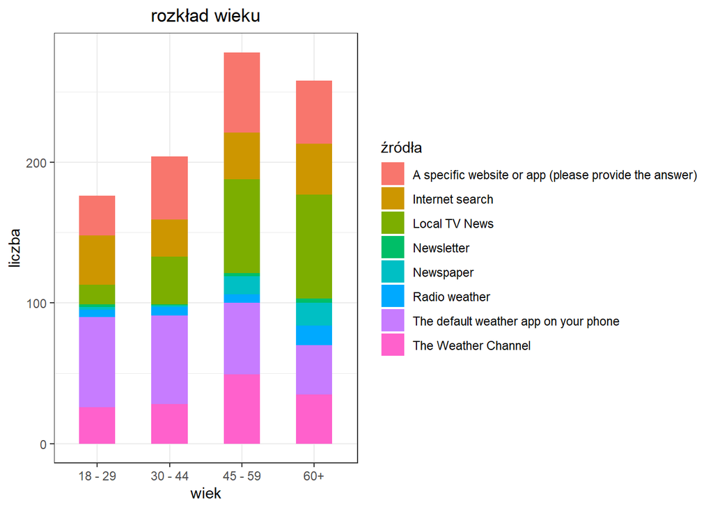

```r
ggplot(weather_check, aes(x = age,fill = weather_source ))+theme_bw() +
  stat_count(width = 0.5) +
  labs(y="liczba",x="wiek", title="rozkład wieku") +
  scale_fill_discrete(name="źródła")+
  theme(plot.title = element_text(hjust = 0.5))+
  scale_x_discrete(na.translate = FALSE)
```